# Risk Factor Analysis

## Outcome Variable

**Outcome Variable:** ever_stunted

## Predictor Variables

**Intervention Variable:** tr.x

**Adjustment Set:**

unadjusted

## Stratifying Variables

The analysis was stratified on these variable(s):

- vagbrth
- agecat
- studyid
- country

## Data Summary

| vagbrth | agecat | studyid | country | tr.x | ever_stunted | n_cell | n |
| --- | --- | --- | --- | --- | --- | --- | --- |
| 0 | 0-6 months | ki1017093b-PROVIDE | BANGLADESH | Control | 0 | 31 | 147 |
| 0 | 0-6 months | ki1017093b-PROVIDE | BANGLADESH | Control | 1 | 7 | 147 |
| 0 | 0-6 months | ki1017093b-PROVIDE | BANGLADESH | Other | 0 | 96 | 147 |
| 0 | 0-6 months | ki1017093b-PROVIDE | BANGLADESH | Other | 1 | 13 | 147 |
| 1 | 0-6 months | ki1017093b-PROVIDE | BANGLADESH | Control | 0 | 111 | 493 |
| 1 | 0-6 months | ki1017093b-PROVIDE | BANGLADESH | Control | 1 | 17 | 493 |
| 1 | 0-6 months | ki1017093b-PROVIDE | BANGLADESH | Other | 0 | 313 | 493 |
| 1 | 0-6 months | ki1017093b-PROVIDE | BANGLADESH | Other | 1 | 52 | 493 |
| 1 | 0-6 months | ki1066203-TanzaniaChild2 | TANZANIA, UNITED REPUBLIC OF | Control | 0 | 473 | 2004 |
| 1 | 0-6 months | ki1066203-TanzaniaChild2 | TANZANIA, UNITED REPUBLIC OF | Control | 1 | 38 | 2004 |
| 1 | 0-6 months | ki1066203-TanzaniaChild2 | TANZANIA, UNITED REPUBLIC OF | Other | 0 | 929 | 2004 |
| 1 | 0-6 months | ki1066203-TanzaniaChild2 | TANZANIA, UNITED REPUBLIC OF | Other | 1 | 62 | 2004 |
| 1 | 0-6 months | ki1066203-TanzaniaChild2 | TANZANIA, UNITED REPUBLIC OF | Zinc | 0 | 458 | 2004 |
| 1 | 0-6 months | ki1066203-TanzaniaChild2 | TANZANIA, UNITED REPUBLIC OF | Zinc | 1 | 44 | 2004 |
| 0 | 0-6 months | ki1066203-TanzaniaChild2 | TANZANIA, UNITED REPUBLIC OF | Control | 0 | 42 | 203 |
| 0 | 0-6 months | ki1066203-TanzaniaChild2 | TANZANIA, UNITED REPUBLIC OF | Control | 1 | 2 | 203 |
| 0 | 0-6 months | ki1066203-TanzaniaChild2 | TANZANIA, UNITED REPUBLIC OF | Other | 0 | 98 | 203 |
| 0 | 0-6 months | ki1066203-TanzaniaChild2 | TANZANIA, UNITED REPUBLIC OF | Other | 1 | 9 | 203 |
| 0 | 0-6 months | ki1066203-TanzaniaChild2 | TANZANIA, UNITED REPUBLIC OF | Zinc | 0 | 49 | 203 |
| 0 | 0-6 months | ki1066203-TanzaniaChild2 | TANZANIA, UNITED REPUBLIC OF | Zinc | 1 | 3 | 203 |
| 1 | 0-6 months | ki1119695-PROBIT | BELARUS | Control | 0 | 6522 | 14312 |
| 1 | 0-6 months | ki1119695-PROBIT | BELARUS | Control | 1 | 470 | 14312 |
| 1 | 0-6 months | ki1119695-PROBIT | BELARUS | Other | 0 | 6864 | 14312 |
| 1 | 0-6 months | ki1119695-PROBIT | BELARUS | Other | 1 | 456 | 14312 |
| 0 | 0-6 months | ki1119695-PROBIT | BELARUS | Control | 0 | 752 | 1873 |
| 0 | 0-6 months | ki1119695-PROBIT | BELARUS | Control | 1 | 63 | 1873 |
| 0 | 0-6 months | ki1119695-PROBIT | BELARUS | Other | 0 | 995 | 1873 |
| 0 | 0-6 months | ki1119695-PROBIT | BELARUS | Other | 1 | 63 | 1873 |
| 1 | 0-6 months | ki1126311-ZVITAMBO | ZIMBABWE | Control | 0 | 1722 | 8273 |
| 1 | 0-6 months | ki1126311-ZVITAMBO | ZIMBABWE | Control | 1 | 358 | 8273 |

[output cut: 186 more lines]

The following strata were considered:

- vagbrth: 0, agecat: 0-24 months, studyid: ki1017093b-PROVIDE, country: BANGLADESH
- vagbrth: 0, agecat: 0-24 months, studyid: ki1066203-TanzaniaChild2, country: TANZANIA, UNITED REPUBLIC OF
- vagbrth: 0, agecat: 0-24 months, studyid: ki1119695-PROBIT, country: BELARUS
- vagbrth: 0, agecat: 0-24 months, studyid: ki1126311-ZVITAMBO, country: ZIMBABWE
- vagbrth: 0, agecat: 0-24 months, studyid: ki1148112-iLiNS-DYAD-M, country: MALAWI
- vagbrth: 0, agecat: 0-24 months, studyid: kiGH5241-JiVitA-3, country: BANGLADESH
- vagbrth: 0, agecat: 0-24 months, studyid: kiGH5241-JiVitA-4, country: BANGLADESH
- vagbrth: 0, agecat: 0-6 months, studyid: ki1017093b-PROVIDE, country: BANGLADESH
- vagbrth: 0, agecat: 0-6 months, studyid: ki1066203-TanzaniaChild2, country: TANZANIA, UNITED REPUBLIC OF
- vagbrth: 0, agecat: 0-6 months, studyid: ki1119695-PROBIT, country: BELARUS
- vagbrth: 0, agecat: 0-6 months, studyid: ki1126311-ZVITAMBO, country: ZIMBABWE
- vagbrth: 0, agecat: 0-6 months, studyid: ki1148112-iLiNS-DYAD-M, country: MALAWI
- vagbrth: 0, agecat: 0-6 months, studyid: kiGH5241-JiVitA-3, country: BANGLADESH
- vagbrth: 0, agecat: 0-6 months, studyid: kiGH5241-JiVitA-4, country: BANGLADESH
- vagbrth: 0, agecat: 6-24 months, studyid: ki1017093b-PROVIDE, country: BANGLADESH
- vagbrth: 0, agecat: 6-24 months, studyid: ki1066203-TanzaniaChild2, country: TANZANIA, UNITED REPUBLIC OF
- vagbrth: 0, agecat: 6-24 months, studyid: ki1119695-PROBIT, country: BELARUS
- vagbrth: 0, agecat: 6-24 months, studyid: ki1126311-ZVITAMBO, country: ZIMBABWE
- vagbrth: 0, agecat: 6-24 months, studyid: ki1148112-iLiNS-DYAD-M, country: MALAWI
- vagbrth: 0, agecat: 6-24 months, studyid: kiGH5241-JiVitA-3, country: BANGLADESH
- vagbrth: 0, agecat: 6-24 months, studyid: kiGH5241-JiVitA-4, country: BANGLADESH
- vagbrth: 1, agecat: 0-24 months, studyid: ki1017093b-PROVIDE, country: BANGLADESH
- vagbrth: 1, agecat: 0-24 months, studyid: ki1066203-TanzaniaChild2, country: TANZANIA, UNITED REPUBLIC OF
- vagbrth: 1, agecat: 0-24 months, studyid: ki1119695-PROBIT, country: BELARUS
- vagbrth: 1, agecat: 0-24 months, studyid: ki1126311-ZVITAMBO, country: ZIMBABWE
- vagbrth: 1, agecat: 0-24 months, studyid: ki1148112-iLiNS-DYAD-M, country: MALAWI
- vagbrth: 1, agecat: 0-24 months, studyid: kiGH5241-JiVitA-3, country: BANGLADESH
- vagbrth: 1, agecat: 0-24 months, studyid: kiGH5241-JiVitA-4, country: BANGLADESH
- vagbrth: 1, agecat: 0-6 months, studyid: ki1017093b-PROVIDE, country: BANGLADESH
- vagbrth: 1, agecat: 0-6 months, studyid: ki1066203-TanzaniaChild2, country: TANZANIA, UNITED REPUBLIC OF
- vagbrth: 1, agecat: 0-6 months, studyid: ki1119695-PROBIT, country: BELARUS
- vagbrth: 1, agecat: 0-6 months, studyid: ki1126311-ZVITAMBO, country: ZIMBABWE
- vagbrth: 1, agecat: 0-6 months, studyid: ki1148112-iLiNS-DYAD-M, country: MALAWI
- vagbrth: 1, agecat: 0-6 months, studyid: kiGH5241-JiVitA-3, country: BANGLADESH
- vagbrth: 1, agecat: 0-6 months, studyid: kiGH5241-JiVitA-4, country: BANGLADESH
- vagbrth: 1, agecat: 6-24 months, studyid: ki1017093b-PROVIDE, country: BANGLADESH
- vagbrth: 1, agecat: 6-24 months, studyid: ki1066203-TanzaniaChild2, country: TANZANIA, UNITED REPUBLIC OF
- vagbrth: 1, agecat: 6-24 months, studyid: ki1119695-PROBIT, country: BELARUS
- vagbrth: 1, agecat: 6-24 months, studyid: ki1126311-ZVITAMBO, country: ZIMBABWE
- vagbrth: 1, agecat: 6-24 months, studyid: ki1148112-iLiNS-DYAD-M, country: MALAWI
- vagbrth: 1, agecat: 6-24 months, studyid: kiGH5241-JiVitA-3, country: BANGLADESH
- vagbrth: 1, agecat: 6-24 months, studyid: kiGH5241-JiVitA-4, country: BANGLADESH

### Dropped Strata

Some strata were dropped due to rare outcomes:

- vagbrth: 0, agecat: 0-6 months, studyid: ki1066203-TanzaniaChild2, country: TANZANIA, UNITED REPUBLIC OF
- vagbrth: 1, agecat: 0-6 months, studyid: ki1148112-iLiNS-DYAD-M, country: MALAWI
- vagbrth: 0, agecat: 0-6 months, studyid: ki1148112-iLiNS-DYAD-M, country: MALAWI
- vagbrth: 0, agecat: 6-24 months, studyid: ki1066203-TanzaniaChild2, country: TANZANIA, UNITED REPUBLIC OF
- vagbrth: 0, agecat: 6-24 months, studyid: ki1148112-iLiNS-DYAD-M, country: MALAWI

## Methods Detail

We’re interested in the causal parameters $E[Y_a]$ for all values of $a \in \mathcal{A}$. These parameters represent the mean outcome if, possibly contrary to fact, we intervened to set all units to have $A=a$. Under the randomization and positivity assumptions, these are identified by the statistical parameters $\psi_a=E_W[E_{Y|A,W}(Y|A=a,W)]$. In addition, we’re interested in the mean of $Y$, $E[Y]$ under no intervention (the observed mean). We will estimate these parameters by using SuperLearner to fit the relevant likelihood factors – $E_{Y|A,W}(Y|A=a,W)$ and $p(A=a|W)$, and then updating our likelihood fit using a joint TMLE.

For unadjusted analyses ($W=\{\}$), initial likelihoods were estimated using Lrnr_glm to estimate the simple $E(Y|A)$ and Lrnr_mean to estimate $p(A)$. For adjusted analyses, a small library containing Lrnr_glmnet, Lrnr_xgboost, and Lrnr_mean was used.

Having estimated these parameters, we will then use the delta method to estimate relative risks and attributable risks relative to a prespecified baseline level of $A$.

# Results Detail

## Results Plots

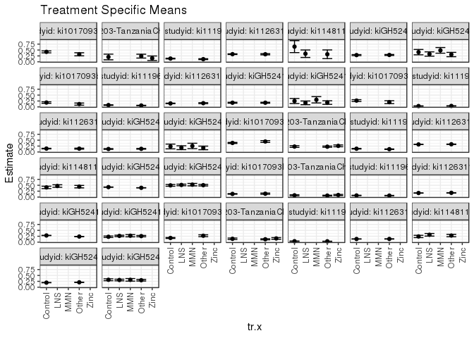

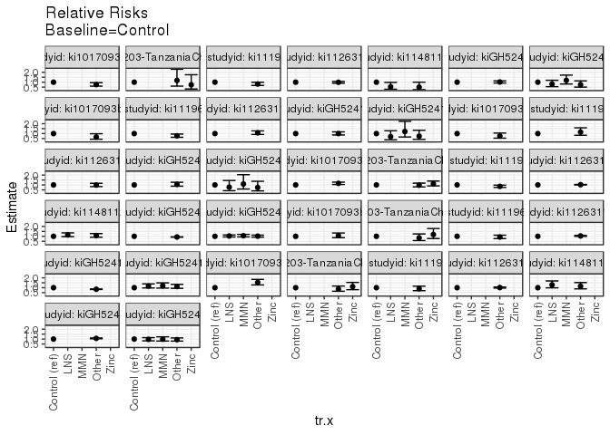

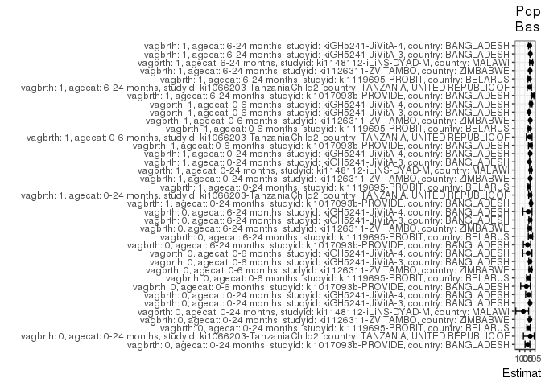

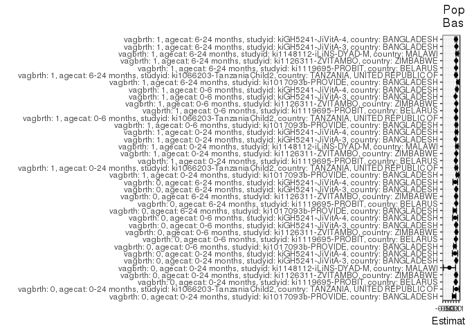

## Results Table

### Parameter: TSM

| vagbrth | agecat | studyid | country | intervention_level | baseline_level | estimate | ci_lower | ci_upper |
| --- | --- | --- | --- | --- | --- | --- | --- | --- |
| 0 | 0-24 months | ki1017093b-PROVIDE | BANGLADESH | Control | NA | 0.4210526 | 0.3806101 | 0.4614951 |
| 0 | 0-24 months | ki1017093b-PROVIDE | BANGLADESH | Other | NA | 0.3181818 | 0.2532695 | 0.3830941 |
| 0 | 0-24 months | ki1066203-TanzaniaChild2 | TANZANIA, UNITED REPUBLIC OF | Control | NA | 0.2045455 | 0.0850679 | 0.3240230 |
| 0 | 0-24 months | ki1066203-TanzaniaChild2 | TANZANIA, UNITED REPUBLIC OF | Other | NA | 0.2407407 | 0.1599116 | 0.3215699 |
| 0 | 0-24 months | ki1066203-TanzaniaChild2 | TANZANIA, UNITED REPUBLIC OF | Zinc | NA | 0.1509434 | 0.0543278 | 0.2475590 |
| 0 | 0-24 months | ki1119695-PROBIT | BELARUS | Control | NA | 0.1376038 | 0.1211960 | 0.1540116 |
| 0 | 0-24 months | ki1119695-PROBIT | BELARUS | Other | NA | 0.1122263 | 0.0941334 | 0.1303191 |
| 0 | 0-24 months | ki1126311-ZVITAMBO | ZIMBABWE | Control | NA | 0.3241107 | 0.3093497 | 0.3388717 |
| 0 | 0-24 months | ki1126311-ZVITAMBO | ZIMBABWE | Other | NA | 0.3206522 | 0.2955464 | 0.3457579 |
| 0 | 0-24 months | ki1148112-iLiNS-DYAD-M | MALAWI | Control | NA | 0.6428571 | 0.3901505 | 0.8955638 |
| 0 | 0-24 months | ki1148112-iLiNS-DYAD-M | MALAWI | LNS | NA | 0.3428571 | 0.1845301 | 0.5011841 |
| 0 | 0-24 months | ki1148112-iLiNS-DYAD-M | MALAWI | Other | NA | 0.3200000 | 0.1358965 | 0.5041035 |
| 0 | 0-24 months | kiGH5241-JiVitA-3 | BANGLADESH | Control | NA | 0.2844037 | 0.2626340 | 0.3061733 |
| 0 | 0-24 months | kiGH5241-JiVitA-3 | BANGLADESH | Other | NA | 0.2899408 | 0.2688197 | 0.3110620 |
| 0 | 0-24 months | kiGH5241-JiVitA-4 | BANGLADESH | Control | NA | 0.4096386 | 0.2961127 | 0.5231644 |
| 0 | 0-24 months | kiGH5241-JiVitA-4 | BANGLADESH | LNS | NA | 0.3305085 | 0.2395437 | 0.4214732 |
| 0 | 0-24 months | kiGH5241-JiVitA-4 | BANGLADESH | MMN | NA | 0.4838710 | 0.3641337 | 0.6036083 |
| 0 | 0-24 months | kiGH5241-JiVitA-4 | BANGLADESH | Other | NA | 0.3084112 | 0.2161487 | 0.4006737 |
| 0 | 0-6 months | ki1017093b-PROVIDE | BANGLADESH | Control | NA | 0.1842105 | 0.1522399 | 0.2161811 |
| 0 | 0-6 months | ki1017093b-PROVIDE | BANGLADESH | Other | NA | 0.1192661 | 0.0739964 | 0.1645357 |
| 0 | 0-6 months | ki1119695-PROBIT | BELARUS | Control | NA | 0.0773006 | 0.0658493 | 0.0887519 |
| 0 | 0-6 months | ki1119695-PROBIT | BELARUS | Other | NA | 0.0595463 | 0.0507778 | 0.0683149 |
| 0 | 0-6 months | ki1126311-ZVITAMBO | ZIMBABWE | Control | NA | 0.1465969 | 0.1340153 | 0.1591784 |
| 0 | 0-6 months | ki1126311-ZVITAMBO | ZIMBABWE | Other | NA | 0.1576182 | 0.1352076 | 0.1800288 |
| 0 | 0-6 months | kiGH5241-JiVitA-3 | BANGLADESH | Control | NA | 0.1763636 | 0.1566983 | 0.1960290 |
| 0 | 0-6 months | kiGH5241-JiVitA-3 | BANGLADESH | Other | NA | 0.1767956 | 0.1574266 | 0.1961646 |
| 0 | 0-6 months | kiGH5241-JiVitA-4 | BANGLADESH | Control | NA | 0.2500000 | 0.1429485 | 0.3570515 |
| 0 | 0-6 months | kiGH5241-JiVitA-4 | BANGLADESH | LNS | NA | 0.1714286 | 0.0927656 | 0.2500916 |
| 0 | 0-6 months | kiGH5241-JiVitA-4 | BANGLADESH | MMN | NA | 0.3018868 | 0.1681946 | 0.4355790 |
| 0 | 0-6 months | kiGH5241-JiVitA-4 | BANGLADESH | Other | NA | 0.1836735 | 0.1081441 | 0.2592028 |

[output cut: 63 more lines]

### Parameter: E(Y)

| vagbrth | agecat | studyid | country | intervention_level | baseline_level | estimate | ci_lower | ci_upper |
| --- | --- | --- | --- | --- | --- | --- | --- | --- |
| 0 | 0-24 months | ki1017093b-PROVIDE | BANGLADESH | NA | NA | 0.3445946 | 0.2677703 | 0.4214189 |
| 0 | 0-24 months | ki1066203-TanzaniaChild2 | TANZANIA, UNITED REPUBLIC OF | NA | NA | 0.2097561 | 0.1538871 | 0.2656251 |
| 0 | 0-24 months | ki1119695-PROBIT | BELARUS | NA | NA | 0.1232594 | 0.0980729 | 0.1484460 |
| 0 | 0-24 months | ki1126311-ZVITAMBO | ZIMBABWE | NA | NA | 0.3215369 | 0.2924131 | 0.3506607 |
| 0 | 0-24 months | ki1148112-iLiNS-DYAD-M | MALAWI | NA | NA | 0.3918919 | 0.2799068 | 0.5038770 |
| 0 | 0-24 months | kiGH5241-JiVitA-3 | BANGLADESH | NA | NA | 0.2872180 | 0.2568875 | 0.3175486 |
| 0 | 0-24 months | kiGH5241-JiVitA-4 | BANGLADESH | NA | NA | 0.3675676 | 0.3160145 | 0.4191206 |
| 0 | 0-6 months | ki1017093b-PROVIDE | BANGLADESH | NA | NA | 0.1360544 | 0.0804421 | 0.1916668 |
| 0 | 0-6 months | ki1119695-PROBIT | BELARUS | NA | NA | 0.0672718 | 0.0522083 | 0.0823352 |
| 0 | 0-6 months | ki1126311-ZVITAMBO | ZIMBABWE | NA | NA | 0.1548556 | 0.1291526 | 0.1805587 |
| 0 | 0-6 months | kiGH5241-JiVitA-3 | BANGLADESH | NA | NA | 0.1765782 | 0.1489762 | 0.2041803 |
| 0 | 0-6 months | kiGH5241-JiVitA-4 | BANGLADESH | NA | NA | 0.2134146 | 0.1663281 | 0.2605011 |
| 0 | 6-24 months | ki1017093b-PROVIDE | BANGLADESH | NA | NA | 0.2160000 | 0.1435694 | 0.2884306 |
| 0 | 6-24 months | ki1119695-PROBIT | BELARUS | NA | NA | 0.0382369 | 0.0260951 | 0.0503786 |
| 0 | 6-24 months | ki1126311-ZVITAMBO | ZIMBABWE | NA | NA | 0.1419598 | 0.1176992 | 0.1662204 |
| 0 | 6-24 months | kiGH5241-JiVitA-3 | BANGLADESH | NA | NA | 0.1300728 | 0.1057819 | 0.1543638 |
| 0 | 6-24 months | kiGH5241-JiVitA-4 | BANGLADESH | NA | NA | 0.2006173 | 0.1553511 | 0.2458835 |
| 1 | 0-24 months | ki1017093b-PROVIDE | BANGLADESH | NA | NA | 0.4279919 | 0.3842715 | 0.4717123 |
| 1 | 0-24 months | ki1066203-TanzaniaChild2 | TANZANIA, UNITED REPUBLIC OF | NA | NA | 0.2347998 | 0.2163244 | 0.2532752 |
| 1 | 0-24 months | ki1119695-PROBIT | BELARUS | NA | NA | 0.1281427 | 0.1096604 | 0.1466251 |
| 1 | 0-24 months | ki1126311-ZVITAMBO | ZIMBABWE | NA | NA | 0.3256226 | 0.3167519 | 0.3344933 |
| 1 | 0-24 months | ki1148112-iLiNS-DYAD-M | MALAWI | NA | NA | 0.4390935 | 0.4091723 | 0.4690147 |
| 1 | 0-24 months | kiGH5241-JiVitA-3 | BANGLADESH | NA | NA | 0.4067284 | 0.3982469 | 0.4152099 |
| 1 | 0-24 months | kiGH5241-JiVitA-4 | BANGLADESH | NA | NA | 0.5081967 | 0.4896095 | 0.5267840 |
| 1 | 0-6 months | ki1017093b-PROVIDE | BANGLADESH | NA | NA | 0.1399594 | 0.1093027 | 0.1706162 |
| 1 | 0-6 months | ki1066203-TanzaniaChild2 | TANZANIA, UNITED REPUBLIC OF | NA | NA | 0.0718563 | 0.0605467 | 0.0831659 |
| 1 | 0-6 months | ki1119695-PROBIT | BELARUS | NA | NA | 0.0647010 | 0.0523985 | 0.0770034 |
| 1 | 0-6 months | ki1126311-ZVITAMBO | ZIMBABWE | NA | NA | 0.1773238 | 0.1690930 | 0.1855546 |
| 1 | 0-6 months | kiGH5241-JiVitA-3 | BANGLADESH | NA | NA | 0.2599956 | 0.2524939 | 0.2674973 |
| 1 | 0-6 months | kiGH5241-JiVitA-4 | BANGLADESH | NA | NA | 0.2539376 | 0.2374486 | 0.2704265 |
| 1 | 6-24 months | ki1017093b-PROVIDE | BANGLADESH | NA | NA | 0.2473118 | 0.2034091 | 0.2912145 |
| 1 | 6-24 months | ki1066203-TanzaniaChild2 | TANZANIA, UNITED REPUBLIC OF | NA | NA | 0.1359223 | 0.1193714 | 0.1524733 |
| 1 | 6-24 months | ki1119695-PROBIT | BELARUS | NA | NA | 0.0380028 | 0.0280563 | 0.0479492 |
| 1 | 6-24 months | ki1126311-ZVITAMBO | ZIMBABWE | NA | NA | 0.1350231 | 0.1277330 | 0.1423132 |
| 1 | 6-24 months | ki1148112-iLiNS-DYAD-M | MALAWI | NA | NA | 0.2766204 | 0.2467476 | 0.3064931 |
| 1 | 6-24 months | kiGH5241-JiVitA-3 | BANGLADESH | NA | NA | 0.2021996 | 0.1938335 | 0.2105657 |
| 1 | 6-24 months | kiGH5241-JiVitA-4 | BANGLADESH | NA | NA | 0.3078576 | 0.2885174 | 0.3271977 |

### Parameter: RR

| vagbrth | agecat | studyid | country | intervention_level | baseline_level | estimate | ci_lower | ci_upper |
| --- | --- | --- | --- | --- | --- | --- | --- | --- |
| 0 | 0-24 months | ki1017093b-PROVIDE | BANGLADESH | Control | Control | 1.0000000 | 1.0000000 | 1.0000000 |
| 0 | 0-24 months | ki1017093b-PROVIDE | BANGLADESH | Other | Control | 0.7556818 | 0.6031284 | 0.9468216 |
| 0 | 0-24 months | ki1066203-TanzaniaChild2 | TANZANIA, UNITED REPUBLIC OF | Control | Control | 1.0000000 | 1.0000000 | 1.0000000 |
| 0 | 0-24 months | ki1066203-TanzaniaChild2 | TANZANIA, UNITED REPUBLIC OF | Other | Control | 1.1769547 | 0.6000137 | 2.3086515 |
| 0 | 0-24 months | ki1066203-TanzaniaChild2 | TANZANIA, UNITED REPUBLIC OF | Zinc | Control | 0.7379455 | 0.3102357 | 1.7553223 |
| 0 | 0-24 months | ki1119695-PROBIT | BELARUS | Control | Control | 1.0000000 | 1.0000000 | 1.0000000 |
| 0 | 0-24 months | ki1119695-PROBIT | BELARUS | Other | Control | 0.8155754 | 0.6672705 | 0.9968421 |
| 0 | 0-24 months | ki1126311-ZVITAMBO | ZIMBABWE | Control | Control | 1.0000000 | 1.0000000 | 1.0000000 |
| 0 | 0-24 months | ki1126311-ZVITAMBO | ZIMBABWE | Other | Control | 0.9893293 | 0.9036561 | 1.0831249 |
| 0 | 0-24 months | ki1148112-iLiNS-DYAD-M | MALAWI | Control | Control | 1.0000000 | 1.0000000 | 1.0000000 |
| 0 | 0-24 months | ki1148112-iLiNS-DYAD-M | MALAWI | LNS | Control | 0.5333333 | 0.2908194 | 0.9780792 |
| 0 | 0-24 months | ki1148112-iLiNS-DYAD-M | MALAWI | Other | Control | 0.4977778 | 0.2479825 | 0.9991943 |
| 0 | 0-24 months | kiGH5241-JiVitA-3 | BANGLADESH | Control | Control | 1.0000000 | 1.0000000 | 1.0000000 |
| 0 | 0-24 months | kiGH5241-JiVitA-3 | BANGLADESH | Other | Control | 1.0194694 | 0.9172411 | 1.1330912 |
| 0 | 0-24 months | kiGH5241-JiVitA-4 | BANGLADESH | Control | Control | 1.0000000 | 1.0000000 | 1.0000000 |
| 0 | 0-24 months | kiGH5241-JiVitA-4 | BANGLADESH | LNS | Control | 0.8068295 | 0.5459378 | 1.1923956 |
| 0 | 0-24 months | kiGH5241-JiVitA-4 | BANGLADESH | MMN | Control | 1.1812144 | 0.8145786 | 1.7128704 |
| 0 | 0-24 months | kiGH5241-JiVitA-4 | BANGLADESH | Other | Control | 0.7528862 | 0.5006617 | 1.1321769 |
| 0 | 0-6 months | ki1017093b-PROVIDE | BANGLADESH | Control | Control | 1.0000000 | 1.0000000 | 1.0000000 |
| 0 | 0-6 months | ki1017093b-PROVIDE | BANGLADESH | Other | Control | 0.6474443 | 0.4265236 | 0.9827922 |
| 0 | 0-6 months | ki1119695-PROBIT | BELARUS | Control | Control | 1.0000000 | 1.0000000 | 1.0000000 |
| 0 | 0-6 months | ki1119695-PROBIT | BELARUS | Other | Control | 0.7703214 | 0.6253331 | 0.9489262 |
| 0 | 0-6 months | ki1126311-ZVITAMBO | ZIMBABWE | Control | Control | 1.0000000 | 1.0000000 | 1.0000000 |
| 0 | 0-6 months | ki1126311-ZVITAMBO | ZIMBABWE | Other | Control | 1.0751814 | 0.9106576 | 1.2694288 |
| 0 | 0-6 months | kiGH5241-JiVitA-3 | BANGLADESH | Control | Control | 1.0000000 | 1.0000000 | 1.0000000 |
| 0 | 0-6 months | kiGH5241-JiVitA-3 | BANGLADESH | Other | Control | 1.0024492 | 0.8573801 | 1.1720639 |
| 0 | 0-6 months | kiGH5241-JiVitA-4 | BANGLADESH | Control | Control | 1.0000000 | 1.0000000 | 1.0000000 |
| 0 | 0-6 months | kiGH5241-JiVitA-4 | BANGLADESH | LNS | Control | 0.6857143 | 0.3660600 | 1.2845001 |
| 0 | 0-6 months | kiGH5241-JiVitA-4 | BANGLADESH | MMN | Control | 1.2075472 | 0.6523515 | 2.2352522 |
| 0 | 0-6 months | kiGH5241-JiVitA-4 | BANGLADESH | Other | Control | 0.7346939 | 0.4056829 | 1.3305344 |

[output cut: 63 more lines]

### Parameter: PAR

| vagbrth | agecat | studyid | country | intervention_level | baseline_level | estimate | ci_lower | ci_upper |
| --- | --- | --- | --- | --- | --- | --- | --- | --- |
| 0 | 0-24 months | ki1017093b-PROVIDE | BANGLADESH | Control | NA | -0.0764580 | -0.1417756 | -0.0111405 |
| 0 | 0-24 months | ki1066203-TanzaniaChild2 | TANZANIA, UNITED REPUBLIC OF | Control | NA | 0.0052106 | -0.1009424 | 0.1113637 |
| 0 | 0-24 months | ki1119695-PROBIT | BELARUS | Control | NA | -0.0143444 | -0.0329388 | 0.0042500 |
| 0 | 0-24 months | ki1126311-ZVITAMBO | ZIMBABWE | Control | NA | -0.0025738 | -0.0276797 | 0.0225322 |
| 0 | 0-24 months | ki1148112-iLiNS-DYAD-M | MALAWI | Control | NA | -0.2509653 | -0.4795212 | -0.0224093 |
| 0 | 0-24 months | kiGH5241-JiVitA-3 | BANGLADESH | Control | NA | 0.0028144 | -0.0183079 | 0.0239366 |
| 0 | 0-24 months | kiGH5241-JiVitA-4 | BANGLADESH | Control | NA | -0.0420710 | -0.1410996 | 0.0569577 |
| 0 | 0-6 months | ki1017093b-PROVIDE | BANGLADESH | Control | NA | -0.0481561 | -0.0936601 | -0.0026521 |
| 0 | 0-6 months | ki1119695-PROBIT | BELARUS | Control | NA | -0.0100289 | -0.0194819 | -0.0005758 |
| 0 | 0-6 months | ki1126311-ZVITAMBO | ZIMBABWE | Control | NA | 0.0082588 | -0.0141544 | 0.0306720 |
| 0 | 0-6 months | kiGH5241-JiVitA-3 | BANGLADESH | Control | NA | 0.0002146 | -0.0191544 | 0.0195836 |
| 0 | 0-6 months | kiGH5241-JiVitA-4 | BANGLADESH | Control | NA | -0.0365854 | -0.1297160 | 0.0565453 |
| 0 | 6-24 months | ki1017093b-PROVIDE | BANGLADESH | Control | NA | -0.0506667 | -0.1122477 | 0.0109144 |
| 0 | 6-24 months | ki1119695-PROBIT | BELARUS | Control | NA | 0.0029141 | -0.0057467 | 0.0115748 |
| 0 | 6-24 months | ki1126311-ZVITAMBO | ZIMBABWE | Control | NA | -0.0016046 | -0.0225284 | 0.0193193 |
| 0 | 6-24 months | kiGH5241-JiVitA-3 | BANGLADESH | Control | NA | 0.0034906 | -0.0130706 | 0.0200517 |
| 0 | 6-24 months | kiGH5241-JiVitA-4 | BANGLADESH | Control | NA | -0.0322594 | -0.1195317 | 0.0550129 |
| 1 | 0-24 months | ki1017093b-PROVIDE | BANGLADESH | Control | NA | 0.0451794 | 0.0073308 | 0.0830280 |
| 1 | 0-24 months | ki1066203-TanzaniaChild2 | TANZANIA, UNITED REPUBLIC OF | Control | NA | 0.0041796 | -0.0272647 | 0.0356240 |
| 1 | 0-24 months | ki1119695-PROBIT | BELARUS | Control | NA | -0.0103295 | -0.0219726 | 0.0013136 |
| 1 | 0-24 months | ki1126311-ZVITAMBO | ZIMBABWE | Control | NA | 0.0056523 | -0.0020351 | 0.0133398 |
| 1 | 0-24 months | ki1148112-iLiNS-DYAD-M | MALAWI | Control | NA | 0.0292574 | -0.0117473 | 0.0702621 |
| 1 | 0-24 months | kiGH5241-JiVitA-3 | BANGLADESH | Control | NA | -0.0146062 | -0.0206105 | -0.0086019 |
| 1 | 0-24 months | kiGH5241-JiVitA-4 | BANGLADESH | Control | NA | 0.0118134 | -0.0198969 | 0.0435236 |
| 1 | 0-6 months | ki1017093b-PROVIDE | BANGLADESH | Control | NA | 0.0071469 | -0.0194305 | 0.0337243 |
| 1 | 0-6 months | ki1066203-TanzaniaChild2 | TANZANIA, UNITED REPUBLIC OF | Control | NA | -0.0025077 | -0.0220423 | 0.0170269 |
| 1 | 0-6 months | ki1119695-PROBIT | BELARUS | Control | NA | -0.0025187 | -0.0103087 | 0.0052713 |
| 1 | 0-6 months | ki1126311-ZVITAMBO | ZIMBABWE | Control | NA | 0.0052084 | -0.0019406 | 0.0123575 |
| 1 | 0-6 months | kiGH5241-JiVitA-3 | BANGLADESH | Control | NA | -0.0223599 | -0.0275406 | -0.0171793 |
| 1 | 0-6 months | kiGH5241-JiVitA-4 | BANGLADESH | Control | NA | 0.0257567 | -0.0014341 | 0.0529475 |
| 1 | 6-24 months | ki1017093b-PROVIDE | BANGLADESH | Control | NA | 0.0702285 | 0.0310104 | 0.1094466 |
| 1 | 6-24 months | ki1066203-TanzaniaChild2 | TANZANIA, UNITED REPUBLIC OF | Control | NA | -0.0055871 | -0.0340222 | 0.0228480 |
| 1 | 6-24 months | ki1119695-PROBIT | BELARUS | Control | NA | -0.0020946 | -0.0067679 | 0.0025786 |
| 1 | 6-24 months | ki1126311-ZVITAMBO | ZIMBABWE | Control | NA | 0.0012831 | -0.0050288 | 0.0075949 |
| 1 | 6-24 months | ki1148112-iLiNS-DYAD-M | MALAWI | Control | NA | 0.0350096 | -0.0053339 | 0.0753532 |
| 1 | 6-24 months | kiGH5241-JiVitA-3 | BANGLADESH | Control | NA | 0.0071428 | 0.0009742 | 0.0133114 |
| 1 | 6-24 months | kiGH5241-JiVitA-4 | BANGLADESH | Control | NA | -0.0082279 | -0.0411502 | 0.0246944 |

### Parameter: PAF

| vagbrth | agecat | studyid | country | intervention_level | baseline_level | estimate | ci_lower | ci_upper |
| --- | --- | --- | --- | --- | --- | --- | --- | --- |
| 0 | 0-24 months | ki1017093b-PROVIDE | BANGLADESH | Control | NA | -0.2218782 | -0.4786542 | -0.0096927 |
| 0 | 0-24 months | ki1066203-TanzaniaChild2 | TANZANIA, UNITED REPUBLIC OF | Control | NA | 0.0248414 | -0.6385208 | 0.4196386 |
| 0 | 0-24 months | ki1119695-PROBIT | BELARUS | Control | NA | -0.1163756 | -0.2995508 | 0.0409806 |
| 0 | 0-24 months | ki1126311-ZVITAMBO | ZIMBABWE | Control | NA | -0.0080046 | -0.0898659 | 0.0677080 |
| 0 | 0-24 months | ki1148112-iLiNS-DYAD-M | MALAWI | Control | NA | -0.6403941 | -1.3856280 | -0.1279599 |
| 0 | 0-24 months | kiGH5241-JiVitA-3 | BANGLADESH | Control | NA | 0.0097987 | -0.0657701 | 0.0800093 |
| 0 | 0-24 months | kiGH5241-JiVitA-4 | BANGLADESH | Control | NA | -0.1144578 | -0.4189906 | 0.1247185 |
| 0 | 0-6 months | ki1017093b-PROVIDE | BANGLADESH | Control | NA | -0.3539474 | -0.9023179 | 0.0363475 |
| 0 | 0-6 months | ki1119695-PROBIT | BELARUS | Control | NA | -0.1490798 | -0.3255818 | 0.0039209 |
| 0 | 0-6 months | ki1126311-ZVITAMBO | ZIMBABWE | Control | NA | 0.0533322 | -0.0941759 | 0.1809543 |
| 0 | 0-6 months | kiGH5241-JiVitA-3 | BANGLADESH | Control | NA | 0.0012153 | -0.1145770 | 0.1049780 |
| 0 | 0-6 months | kiGH5241-JiVitA-4 | BANGLADESH | Control | NA | -0.1714286 | -0.6990144 | 0.1923288 |
| 0 | 6-24 months | ki1017093b-PROVIDE | BANGLADESH | Control | NA | -0.2345679 | -0.6450727 | 0.0735012 |
| 0 | 6-24 months | ki1119695-PROBIT | BELARUS | Control | NA | 0.0762113 | -0.1593009 | 0.2638791 |
| 0 | 6-24 months | ki1126311-ZVITAMBO | ZIMBABWE | Control | NA | -0.0113029 | -0.1719107 | 0.1272939 |
| 0 | 6-24 months | kiGH5241-JiVitA-3 | BANGLADESH | Control | NA | 0.0268354 | -0.1053651 | 0.1432250 |
| 0 | 6-24 months | kiGH5241-JiVitA-4 | BANGLADESH | Control | NA | -0.1608008 | -0.6876850 | 0.2015935 |
| 1 | 0-24 months | ki1017093b-PROVIDE | BANGLADESH | Control | NA | 0.1055613 | 0.0226595 | 0.1814310 |
| 1 | 0-24 months | ki1066203-TanzaniaChild2 | TANZANIA, UNITED REPUBLIC OF | Control | NA | 0.0178009 | -0.1256748 | 0.1429896 |
| 1 | 0-24 months | ki1119695-PROBIT | BELARUS | Control | NA | -0.0806092 | -0.1843468 | 0.0140420 |
| 1 | 0-24 months | ki1126311-ZVITAMBO | ZIMBABWE | Control | NA | 0.0173585 | -0.0061174 | 0.0402866 |
| 1 | 0-24 months | ki1148112-iLiNS-DYAD-M | MALAWI | Control | NA | 0.0666314 | -0.0316438 | 0.1555448 |
| 1 | 0-24 months | kiGH5241-JiVitA-3 | BANGLADESH | Control | NA | -0.0359114 | -0.0513222 | -0.0207265 |
| 1 | 0-24 months | kiGH5241-JiVitA-4 | BANGLADESH | Control | NA | 0.0232456 | -0.0412429 | 0.0837401 |
| 1 | 0-6 months | ki1017093b-PROVIDE | BANGLADESH | Control | NA | 0.0510643 | -0.1474823 | 0.2152568 |
| 1 | 0-6 months | ki1066203-TanzaniaChild2 | TANZANIA, UNITED REPUBLIC OF | Control | NA | -0.0348989 | -0.3457448 | 0.2041465 |
| 1 | 0-6 months | ki1119695-PROBIT | BELARUS | Control | NA | -0.0389288 | -0.1721184 | 0.0791263 |
| 1 | 0-6 months | ki1126311-ZVITAMBO | ZIMBABWE | Control | NA | 0.0293725 | -0.0105652 | 0.0677318 |
| 1 | 0-6 months | kiGH5241-JiVitA-3 | BANGLADESH | Control | NA | -0.0860012 | -0.1079143 | -0.0645216 |
| 1 | 0-6 months | kiGH5241-JiVitA-4 | BANGLADESH | Control | NA | 0.1014292 | -0.0123177 | 0.2023953 |
| 1 | 6-24 months | ki1017093b-PROVIDE | BANGLADESH | Control | NA | 0.2839674 | 0.1582951 | 0.3908759 |
| 1 | 6-24 months | ki1066203-TanzaniaChild2 | TANZANIA, UNITED REPUBLIC OF | Control | NA | -0.0411051 | -0.2727574 | 0.1483846 |
| 1 | 6-24 months | ki1119695-PROBIT | BELARUS | Control | NA | -0.0551172 | -0.1941427 | 0.0677226 |
| 1 | 6-24 months | ki1126311-ZVITAMBO | ZIMBABWE | Control | NA | 0.0095026 | -0.0378995 | 0.0547398 |
| 1 | 6-24 months | ki1148112-iLiNS-DYAD-M | MALAWI | Control | NA | 0.1265620 | -0.0319193 | 0.2607039 |
| 1 | 6-24 months | kiGH5241-JiVitA-3 | BANGLADESH | Control | NA | 0.0353256 | 0.0054255 | 0.0643267 |
| 1 | 6-24 months | kiGH5241-JiVitA-4 | BANGLADESH | Control | NA | -0.0267263 | -0.1392906 | 0.0747163 |